# Simulation of Multiple Samples/Tests to Illustrate Power

Fred Clavel, Ph.D.

11 Mar 2021

- [Website](http://fredclavel.org)
- [Github](http://github.com/fdclavel)
- [Twitter](http://twitter.com/fdclavel)

*Back to repository home*

## Introduction

The purpose of this script is to enable demonstrations of the effects of essential characteristics of data on the power to detect a known population effect.

It is designed to simulate data and allow for the following:

- Adjustment of number of data sets (default is 200)
- Adjustment of sample size per data set (each is a considered a random redraw from a population of 10,000)
- Adjustment of magnitude of effect (default is a correlation of r = .30 (medium effect) between 2 variables)

Each adjustable characteristic above (particularly #2 and #3) is related to power.

Results will include a summarized figure detailing results of all tests across each data set, indicating which were statistically significant and which were not, based on their confidence intervals. We will assume a standard alpha = .05 (i.e., the typical *p* value criterion we use in many sciences)

## Package preparation

This process requires the following packages

```r
require(mvnorm)
require(MASS)
require(dplyr)
require(ggplot2)
require(DT)
require(tibble)
```

## Simulating data sets

By default this program will simulate 200 data sets, each containing 100 random observations of two variables X1 and X2 drawn from a larger population of 10,000 people where the actual effect size is known to be r = .30. It will then run the bivariate correlation between X1 and X2 in each sample, and extract those correlation coefficients into a data frame containing the correlations and their confidence intervals.

Each of these defaults can be adjusted by the user if desired. For a tutorial on adjusting the known correlation [please see my article here](https://fredclavel.org/2019/04/17/simulating-correlated-multivariate-data/)

```r
N <- 10000
mu <- c(2,3)
sigma <- matrix(c(9, 3.8, 3.8, 16),2,2)

set.seed(03112021)
pop.data <- data.frame(mvrnorm(n=N, mu=mu, Sigma=sigma))

#check the population correlation
cor(pop.data)
```

```
##           X1        X2
## X1 1.0000000 0.2967115
## X2 0.2967115 1.0000000
```

## Define the adjustable parameters

The two adjustable parameters defined here are :

- *Nsampsize* = The sample size for each random sample (default is 100 observations)
- *Nrandsamps* = The number of random samples of size **Nsampsize** to be drawn

```r
#define adjustable parameters
Nsampsize = 100 #this is the size of each random sample (default 100)
Nrandsamps = 200 #this is the number of random samples to be drawn (default 200)
```

## Draw the random samples from the population and run the tests

This step uses a loop to repeatedly randomly draw **Nsampsize** observations from the population data **Nrandsamps** times, and then conduct the desired analysis and save each result to a new data set containing the results from each of the tests.

```r
#create an empty list object to store the results of each test
results = list()

#use a for loop to extract coefficients and CI values
for(i in 1:Nrandsamps) {
  tempsample <- sample_n(pop.data, Nsampsize)
  tempcor <- cor.test(tempsample$X1, tempsample$X2)
  CI  <- as.data.frame(tempcor$conf.int)
  Rcoeff <- as.numeric(tempcor$estimate)
  CIlow <- CI[1,1]
  CIhigh <- CI[2,1]
  tempdata <- data.frame(cbind(Rcoeff, CIlow, CIhigh))

  #add this iteration of tempdata to the results list
  results[[i]] <- tempdata

}

  #bind all results into a single data frame
    results.data = do.call(rbind, results)
```

```r
    #add the test numbers to the data set.
    testnum = seq(1,nrow(results.data))
    results.data<- cbind(testnum, results.data)

    #view first 6 rows
    table1<-head(results.data)
  datatable(table1)
```

|  | testnum | Rcoeff | CIlow | CIhigh |
| --- | --- | --- | --- | --- |
| 1 | 1 | 0.210897192386503 | 0.0151047753655782 | 0.391113800440532 |
| 2 | 2 | 0.31791355384978 | 0.129587388714358 | 0.484102390645182 |
| 3 | 3 | 0.481946619274221 | 0.315383682166456 | 0.619701869293343 |
| 4 | 4 | 0.178664003520742 | -0.0183998160974029 | 0.362365677815658 |
| 5 | 5 | 0.387476445754757 | 0.206797117821915 | 0.542598783937923 |
| 6 | 6 | 0.130900432051325 | -0.0672466795657563 | 0.319113747103908 |

## Tabulating and Plotting the results

This new data set can then be used to create a plot of significant vs nonsignificant correlation tests, based on the confidence intervals for each correlation coefficient. We can create a table and plot to demonstrate the percentage of tests where the confidence limits contain zero (or conversely those that do not).

```r
#compute a variable to denote significance at p <.05
results.data$sig <- NA
results.data$sig [results.data$CIlow < 0 & results.data$CIhigh > 0] <- "Not Significant"
results.data$sig [results.data$CIlow > 0 & results.data$CIhigh > 0] <- "Significant"
results.data$sig [results.data$CIlow < 0 & results.data$CIhigh < 0] <- "Significant"

table(results.data$sig)
```

```
##
## Not Significant     Significant
##              31             169
```

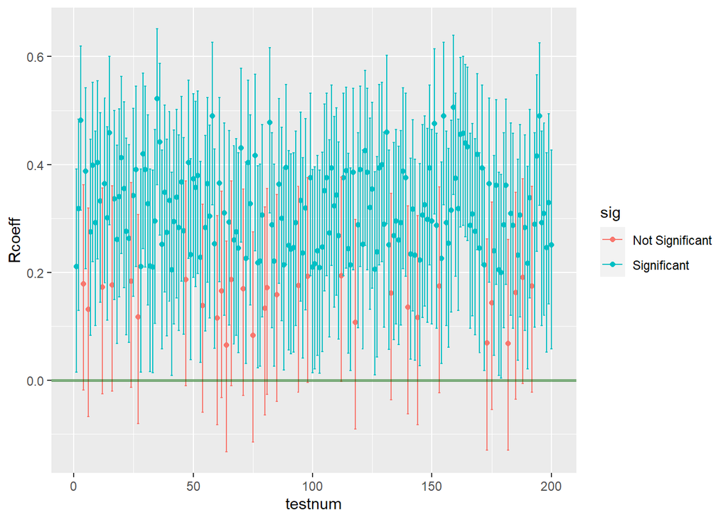

```r
coeff.plot <- ggplot(data = results.data, aes(x=testnum, y=Rcoeff, color=sig))+
      geom_point()+
      geom_errorbar(aes(ymin=CIlow, ymax=CIhigh))+
      geom_hline(yintercept=0, size=1, color="darkgreen", alpha=.5)

coeff.plot
```

## How this tool helps explain power and alpha, relative to sample and effect sizes

The defaults above detected the effect roughly 80% of the time, suggesting that this design has power of about .80 (which is often deemed “acceptable” in psychology).

We can calculate power by hand to verify what the actual value is and see whether the empirical value matches what we expect theoretically [(or just check based on a standard power table. (see page 23))](https://onlinelibrary.wiley.com/doi/pdf/10.1002/9781118342978.app2)

Recall that we have here:

- Population Effect size: rho = .30 (referred to as “rho”)
- Sample Size: N = 100

So the delta value relative to the power to detect this effect would be:

$$\delta = \rho* \sqrt{N-1}$$
$$\delta = .30* \sqrt{100-1}$$
$$\delta = .30* \sqrt{99}$$
$$\delta = .30* 9.95$$
$$\delta = 2.985$$

If we assume alpha = .05, two-tailed (which we are), then **power is about .85** to detect the population correlation of .30 with any 100 random observations we drew from that population (this is based on a standard power table for Pearson correlations). This is roughly consistent what we found based on the empirical demonstration - in the above example, the correlation test was significant in 169 of the 200 simulated random samples from the population (that is, 84.5% of the random samples resulted in a significant correlation, so **our empirically observed power here was .845**).

## Effects of sample size adjustments

**Power is directly affected by sample size, as is statistical significance, as we can demonstrate pretty easily using this tool.** If we run another set of simulated samples, but this time set our sample size at 50, two things will happen:

- Power will decrease, resulting in fewer significant results across all 200 samples.
- The precision of each estimate will decrease, resulting in larger confidence intervals (and therefore fewer significant results) across all 200 samples.

```r
#define adjustable parameters
Nsampsize2 = 50 #this is the size of each random sample (default 100)
Nrandsamps2 = 200 #this is the number of random samples to be drawn (default 200)


#create an empty list object to store the results of each test
results2 = list()

#use a for loop to extract coefficients and CI values
for(i in 1:Nrandsamps2) {
  tempsample <- sample_n(pop.data, Nsampsize2)
  tempcor <- cor.test(tempsample$X1, tempsample$X2)
  CI  <- as.data.frame(tempcor$conf.int)
  Rcoeff <- as.numeric(tempcor$estimate)
  CIlow <- CI[1,1]
  CIhigh <- CI[2,1]
  tempdata2 <- data.frame(cbind(Rcoeff, CIlow, CIhigh))

  #add this iteration of tempdata to the results list
  results2[[i]] <- tempdata2

}

  #bind all results into a single data frame
    results.data2 = do.call(rbind, results2)

    #add the test numbers to the data set.
    testnum2 = seq(1,nrow(results.data2))
    results.data2<- cbind(testnum2, results.data2)

#compute a variable to denote significance at p <.05
results.data2$sig <- NA
results.data2$sig [results.data2$CIlow < 0 & results.data2$CIhigh > 0] <- "Not Significant"
results.data2$sig [results.data2$CIlow > 0 & results.data2$CIhigh > 0] <- "Significant"
results.data2$sig [results.data2$CIlow < 0 & results.data2$CIhigh < 0] <- "Significant"

#tabulate and plot the results
table(results.data2$sig)
```

```
##
## Not Significant     Significant
##              93             107
```

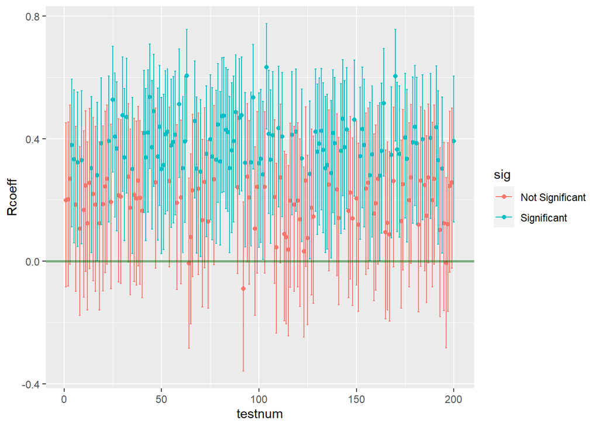

```r
coeff.plot2 <- ggplot(data = results.data2, aes(x=testnum, y=Rcoeff, color=sig))+
      geom_point()+
      geom_errorbar(aes(ymin=CIlow, ymax=CIhigh))+
      geom_hline(yintercept=0, size=1, color="darkgreen", alpha=.5)

coeff.plot2
```

Looking at the results, we can see both effects pretty clearly.

- **Power will decrease, resulting in fewer significant results across all 200 samples** – There are far more red estimates that are nonsignificant, now that the sample size has been halved. *Because only 107 out of 200 tests were significant (or 54%) our observed power has decreased from .85 to about .54* (based on a standard power table, we would expect power of .56 for this design, so what we observed is about the same).
- **The precision of each estimate will decrease, resulting in larger confidence intervals (and therefore fewer significant results) across all 200 samples.** – If we look closely at the Y axis for this 2nd figure, we can see that the upper and lower limits of the confidence intervals have gotten wider than they were in the previous example. This happens because the lower sample size in each sample makes the estimated correlations in each sample less precise - the standard errors get larger, which in turn increases the sizes of all the confidence intervals.

We can actually quickly calculate the average size in both data sets for comparison!

```r
#compute the width by taking the difference between the upper and lower limits
results.data$CIwidth <- results.data$CIhigh - results.data$CIlow
results.data2$CIwidth <- results.data2$CIhigh - results.data2$CIlow

#find the average of each

N100.CIwidth <- mean(results.data$CIwidth, na.rm=T)
N50.CIwidth <- mean(results.data2$CIwidth, na.rm=T)

N100.CIwidth
```

```
## [1] 0.3567993
```

```r
N50.CIwidth
```

```
## [1] 0.5034395
```

In this case, the average width of the confidence intervals around the correlation estimates is different depending on the sample size. When the sample size was 100, the average width of the confidence interval was .36. However, when we cut the sample size in half, the average width of the confidence interval increased to .50.